# OTX2 case study — Fig 3e

Multi-locus browser over 6 EGA gene loci × 7 tracks (OTX2 4C, OTX2 8C, 4C ATAC, 8C H3K4me3, 8C H3K27ac, RNA FGO, RNA 4C). MLT2A1 / HERVL-int is omitted because it is a repeat element not in GENCODE.

External data — 8C histone marks come from Xia 2019 *Science* (GSE124718, paper ref 82); RNA from Zou 2022 *Science* (GSE197265).

Paper: Wang et al. *Nat. Genet.* **57**, 2772-2784 (2025) 10.1038/s41588-025-02350-8

> **Upstream / preprocessing.** FASTQ → BAM → bigwig, MACS2 peak calling, Xia 2019 / Zou 2022 / Gifford 2013 downloads, and the one-off xlsx → TSV extractions are all documented in `preprocess.ipynb`. This notebook starts from the cached inputs under `/scratch/users/steorra/data/otx2/`.

## 1 · Setup

```python
import os, pathlib, warnings
os.environ['PATH'] = '/scratch/users/steorra/env/omicdev/bin:' + os.environ.get('PATH', '')
warnings.filterwarnings('ignore', category=UserWarning)

import numpy as np
import pandas as pd
import matplotlib.pyplot as plt

import epione as epi
epi.pl.plot_set()

DATA         = pathlib.Path('/scratch/users/steorra/data/otx2')
OMIX         = DATA / 'OMIX006476'
ZOU          = DATA / 'GSE197265'
XIA          = DATA / 'GSE124718'
GIFFORD      = DATA / 'GSE61475'
SUPP_TABLES  = DATA / 'supp/supp_tables.xlsx'
GENCODE_GTF  = pathlib.Path('/scratch/users/steorra/data/hg19/gencode.v41lift37.annotation.gtf.gz')
```

[output not shown]

## 2 · Load the 9 bigwigs into one `bigwig` object

Histone marks come as two replicates (Xia 2019 rep1 + rep2); rather than pre-merging we load both and let `plot_track_multi` average them on the fly when a track key is given as a tuple of names.

```python
bw_dict = {
    'OTX2 4C':  str(OMIX / 'h_OTX2_day2_CUTRUN_rep12_pmu_100bp_rpkm_bamCoverage.bw'),
    'OTX2 8C':  str(OMIX / 'h_OTX2_day3_CUTRUN_pmu_100bp_rpkm_bamCoverage.bw'),
    '4C ATAC':  str(OMIX / 'h_OTX2_ctrl_day2_ATAC_reads_count_rep1.bw'),
    'K4me3 r1': str(XIA  / 'GSM3543863_hs_8cell_3PN_H3K4me3_rep1.bw'),
    'K4me3 r2': str(XIA  / 'GSM3543864_hs_8cell_3PN_H3K4me3_rep2.bw'),
    'K27ac r1': str(XIA  / 'GSM3820010_hs_8cell_3PN_H3K27ac_rep1.bw'),
    'K27ac r2': str(XIA  / 'GSM3820011_hs_8cell_3PN_H3K27ac_rep2.bw'),
    'RNA FGO':  str(ZOU  / 'GSE197265_h_GV_rep12_merge_RNA_10bp_rpkm.bw'),
    'RNA 4C':   str(ZOU  / 'GSE197265_h_4C_rep12_merge_RNA_10bp_rpkm.bw'),
}
bw = epi.bulk.bigwig(bw_dict); bw.read()
bw.load_gtf(str(GENCODE_GTF))
```

```
└─ Load bigWig files
  ├─ Loading OTX2 4C...
  ├─ Loading OTX2 8C...
  ├─ Loading 4C ATAC...
  ├─ Loading K4me3 r1...
  ├─ Loading K4me3 r2...
  ├─ Loading K27ac r1...
  ├─ Loading K27ac r2...
  ├─ Loading RNA FGO...
  └─ Loading RNA 4C...
└─ Load GTF file
  ├─ Reading GTF...
  └─ Reading GTF file from /scratch/users/steorra/data/hg19/gencode.v41lift37.annotation.gtf.gz...
```

```
  └─ GTF file read successfully
```

```
  └─ GTF loaded
```

## 3 · Define the 6 loci and plot

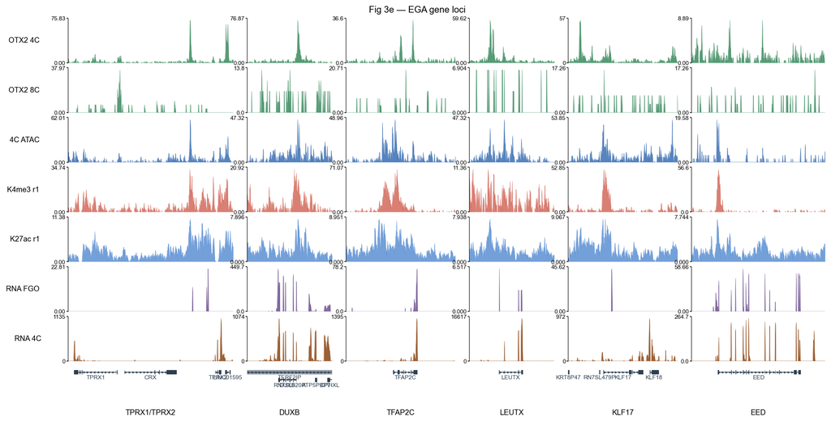

```python
LOCI = [
    ('TPRX1/TPRX2', 'chr19',  48_302_000,  48_370_000),
    ('DUXB',        'chr16',  75_715_000,  75_750_000),
    ('TFAP2C',      'chr20',  55_185_000,  55_230_000),
    ('LEUTX',       'chr19',  40_255_000,  40_290_000),
    ('KLF17',       'chr1',   44_570_000,  44_615_000),
    ('EED',         'chr11',  85_945_000,  86_000_000),
]
# A "track" may be either a single bigwig name or a tuple of names (averaged
# per bin). The tuple form is how plot_track_multi handles replicate marks.
TRACKS = [
    'OTX2 4C', 'OTX2 8C', '4C ATAC',
    ('K4me3 r1','K4me3 r2'),
    ('K27ac r1','K27ac r2'),
    'RNA FGO', 'RNA 4C',
]
COLORS = {'OTX2 4C':'#3A8A5E','OTX2 8C':'#3A8A5E','4C ATAC':'#3A6EB3',
           'K4me3 r1':'#D3695B','K27ac r1':'#5B8FD3',
           'RNA FGO':'#6B4E8C','RNA 4C':'#8B4513'}

fig, axes = bw.plot_track_multi(
    LOCI, bw_names=TRACKS, color_dict=COLORS,
    figwidth=14, figheight=7, title='Fig 3e — EGA gene loci')
plt.show()
```